# peraltav_QC

Peralta Viteri Christian

2023-01-06

# 1 Libraries

```r
library(HDF5Array)
#library(Seurat)
library(SingleCellExperiment) # just for testing
library(cellhashR)
library(DropletUtils)
library(scater)
library(scuttle)
library(scales)
library(ggExtra)

# DropletUtils::read10xCounts()
```

```r
set.seed(12)
```

```r
# rna-seq & atac-seq
h5ls("data/muA/raw_feature_bc_matrix.h5")
```

```
##               group          name       otype  dclass       dim
## 0                 /        matrix   H5I_GROUP
## 1           /matrix      barcodes H5I_DATASET  STRING    730384
## 2           /matrix          data H5I_DATASET INTEGER 163917677
## 3           /matrix      features   H5I_GROUP
## 4  /matrix/features _all_tag_keys H5I_DATASET  STRING         2
## 5  /matrix/features  feature_type H5I_DATASET  STRING    207376
## 6  /matrix/features        genome H5I_DATASET  STRING    207376
## 7  /matrix/features            id H5I_DATASET  STRING    207376
## 8  /matrix/features      interval H5I_DATASET  STRING    207376
## 9  /matrix/features          name H5I_DATASET  STRING    207376
## 10          /matrix       indices H5I_DATASET INTEGER 163917677
## 11          /matrix        indptr H5I_DATASET INTEGER    730385
## 12          /matrix         shape H5I_DATASET INTEGER         2
```

```r
# hto tags
h5ls("data/muA/muAh/raw_feature_bc_matrix.h5")
```

```
##               group          name       otype  dclass     dim
## 0                 /        matrix   H5I_GROUP
## 1           /matrix      barcodes H5I_DATASET  STRING  736320
## 2           /matrix          data H5I_DATASET INTEGER 4511796
## 3           /matrix      features   H5I_GROUP
## 4  /matrix/features _all_tag_keys H5I_DATASET  STRING       4
## 5  /matrix/features  feature_type H5I_DATASET  STRING      15
## 6  /matrix/features        genome H5I_DATASET  STRING      15
## 7  /matrix/features            id H5I_DATASET  STRING      15
## 8  /matrix/features          name H5I_DATASET  STRING      15
## 9  /matrix/features       pattern H5I_DATASET  STRING      15
## 10 /matrix/features          read H5I_DATASET  STRING      15
## 11 /matrix/features      sequence H5I_DATASET  STRING      15
## 12          /matrix       indices H5I_DATASET INTEGER 4511796
## 13          /matrix        indptr H5I_DATASET INTEGER  736321
## 14          /matrix         shape H5I_DATASET INTEGER       2
```

# 2 Data Loading & SCE object creation

```r
sce <- read10xCounts("data/muA/filtered_feature_bc_matrix.h5")
sce <- splitAltExps(sce, rowData(sce)[, "Type"])
sce <- swapAltExp(sce, "Gene Expression")
rownames(sce) <- make.unique(rowData(sce)$Symbol)
colnames(sce) <- colData(sce)$"Barcode"
```

```r
sce
```

```
## class: SingleCellExperiment
## dim: 32285 20000
## metadata(1): Samples
## assays(1): counts
## rownames(32285): Xkr4 Gm1992 ... AC234645.1 AC149090.1
## rowData names(3): ID Symbol Type
## colnames(20000): AAACAGCCAAACCCTA-1 AAACAGCCAATAGTCT-1 ...
##   TTTGTTGGTTTGGCGG-1 TTTGTTGGTTTGTGGA-1
## colData names(2): Sample Barcode
## reducedDimNames(0):
## mainExpName: Gene Expression
## altExpNames(1): Peaks
```

*To add HTOs as metadata, remember to perform the intersection counts-htos*

```r
#htos <- TENxMatrix("data/muA/muAh/raw_feature_bc_matrix.h5")
# using DropletUtils
htos <- read10xCounts("data/muA/muAh/raw_feature_bc_matrix.h5")
colnames(htos) <- colData(htos)$Barcode
htos <- htos[, intersect(colnames(sce), colnames(htos))]
```

```r
#stopifnot(setequal(colnames(htos), colData(sce)[, "Barcode"]))
stopifnot(setequal(colnames(htos), colnames(sce)))
```

*Adding hto information as alternative experiment*

```r
altExp(sce, "hto") <- SummarizedExperiment(assay(htos))
#rm(htos)
```

# 3 Demultiplexing

```r
require(ggplot2)
require(ggExtra)
require(dplyr)
require(cowplot)
require(Matrix)
require(gridExtra)
require(ggrepel)
require(ggpubr)
require(ggnewscale)
require(cellhashR)
```

```r
reticulate::py_config()
```

```
## python:         /mnt/Data/Bioinfo_platf/wyss_project/docker_envi/py_3_10_venv/bin/python
## libpython:      /usr/lib/python3.10/config-3.10-x86_64-linux-gnu/libpython3.10.so
## pythonhome:     /mnt/Data/Bioinfo_platf/wyss_project/docker_envi/py_3_10_venv:/mnt/Data/Bioinfo_platf/wyss_project/docker_envi/py_3_10_venv
## virtualenv:     /mnt/Data/Bioinfo_platf/wyss_project/docker_envi/py_3_10_venv/bin/activate_this.py
## version:        3.10.6 (main, Nov 14 2022, 16:10:14) [GCC 11.3.0]
## numpy:          /mnt/Data/Bioinfo_platf/wyss_project/docker_envi/py_3_10_venv/lib/python3.10/site-packages/numpy
## numpy_version:  1.23.5
##
## NOTE: Python version was forced by RETICULATE_PYTHON
```

```r
HTO_tag=c("HTO-1","HTO-2","HTO-3","HTO-4","HTO-5","HTO-6","HTO-7","HTO-8","HTO-9","HTO-10")
```

**if hto == TRUE** `line 122`

```r
# getting a list of cellbarcode
fileConn <- file(file.path("peralta_qc/out/cellbarcodeWhitelist.txt"))
writeLines(gsub("-", ".", colnames(sce)), fileConn) #it's using seurat, so it's mandatory to gsub
close(fileConn)
```

```r
# swapping experiment to hto and subsetting rownames by HTO-tag, list of interest.
write.table(assay(swapAltExp(sce, "hto"))[rownames(assay(swapAltExp(sce, "hto"))) %in% HTO_tag,],
            file = "peralta_qc/out/hto.txt", sep = ",", col.names = TRUE, row.names = TRUE)
```

```r
pdf(file.path("peralta_qc/pdf/hto.pdf"), width = 20, height = 20)

barcodeData <- ProcessCountMatrix(rawCountData = "peralta_qc/out/hto.txt",
                                  minCountPerCell = 5,
                                  simplifyBarcodeNames = FALSE,
                                  cellbarcodeWhitelist = "peralta_qc/out/cellbarcodeWhitelist.txt",
                                  barcodeWhitelist = HTO_tag)
```

```
## [1] "Initial cell barcodes in hashing data: 20000"
## [1] "cells in cellbarcodeWhitelist file: 20000"
## [1] "intersect between cellbarcodeWhitelist and barcode matrix: 20000"
## [1] "Subsetting based on whitelist. Cells in whitelist: 20000, cells in matrix after subset: 20000"
## [1] "Total cells shared between whitelist and top droplets by count: 20000 (100%)"
```

```
## [1] "Limiting to barcodes: HTO-1,HTO-2,HTO-3,HTO-4,HTO-5,HTO-6,HTO-7,HTO-8,HTO-9,HTO-10"
```

```r
methods=c("multiseq","gmm_demux", "htodemux", "dropletutils")
calls <- GenerateCellHashingCalls(barcodeMatrix = barcodeData,
                                  methods = methods,
                                  doTSNE = FALSE,
                                  majorityConsensusThreshold = 0.3)
```

```
## [1] "Starting Multiseq deMULTIplex"
```

```
## [1] "no negatives, breaking after iteration: 4"
## [1] "Thresholds:"
## [1] "HTO-1: 0.0915934578062199"
## [1] "HTO-2: 1.10016551985454"
## [1] "HTO-3: 0.411943653147959"
## [1] "HTO-4: 1.55856386517065"
## [1] "HTO-5: 2.64808366737294"
## [1] "HTO-6: 0.714306640136002"
## [1] "HTO-7: 0.22366140053748"
## [1] "HTO-8: 0.849751244899797"
## [1] "HTO-9: 0.185661249545402"
## [1] "HTO-10: 1.00543317383064"
```

```
## [1] "Starting GMM-Demux"
## [1] "==============================GMM-Demux Initialization=============================="
## [2] "Confidence threshold: 0.8"
## [3] "Output directory: /tmp/RtmpZxtOFo/file43541eb42a65"
## [4] "Full classification result is stored in /tmp/RtmpZxtOFo/file43543c76926b"
## [5] "MSM-free droplets are stored in folder /tmp/RtmpZxtOFo/file43541eb42a65 "
## [6] ""
```

```
## [1] "Starting HTODemux"
## [1] "Will select bottom 2 barcodes as background"
## [1] "Background clusters for HTO-1: 6,1"
## [1] "total cells for background: 7854"
## [1] "Cutoff for HTO-1 : 860 reads"
## [1] "Will select bottom 2 barcodes as background"
## [1] "Background clusters for HTO-2: 6,1"
## [1] "total cells for background: 7854"
## [1] "Cutoff for HTO-2 : 134 reads"
## [1] "Will select bottom 2 barcodes as background"
## [1] "Background clusters for HTO-3: 6,1"
## [1] "total cells for background: 7854"
## [1] "Cutoff for HTO-3 : 503 reads"
## [1] "Will select bottom 2 barcodes as background"
## [1] "Background clusters for HTO-4: 6,1"
```

[output cut: 37 more lines]

```
## [1] "Starting DropletUtils hashedDrops"
## [1] "Inferred Ambience:"
## [1] "HTO-1: 620.787769284225"
## [1] "HTO-2: 108.237100144671"
## [1] "HTO-3: 379.6593977813"
## [1] "HTO-4: 126.376498116653"
## [1] "HTO-5: 17.7224550286182"
## [1] "HTO-6: 107.568608705432"
## [1] "HTO-7: 218.687335588125"
## [1] "HTO-8: 133.869025317133"
## [1] "HTO-9: 176.565911367051"
## [1] "HTO-10: 288.93306010929"
```

```
## [1] "Generating consensus calls"
## [1] "Consensus calls will be generated using: multiseq,gmm_demux,htodemux,dropletutils"
```

```
## [1] "Total cells recovered using majorityConsensusThreshold of 0.3: 3636"
```

```
## [1] "Total concordant: 19432"
## [1] "Total discordant: 568 (2.84%)"
```

```r
# create summary plots to contrast cells based on call-status. Help inform why some cells were not called
SummarizeCellsByClassification(calls = calls, barcodeMatrix = barcodeData)
dev.off()
```

```r
# reverting name change of barcodes
calls$cellbarcode<-gsub("[.]","-",calls$cellbarcode)
```

```r
# interest in filtering by calls$consensuscall.global
if(filter_singlet==TRUE){sce[, sce$Barcode %in% calls[ calls$consensuscall.global=="Singlet", ]$cellbarcode]}
```

```r
stopifnot(setequal(colnames(sce), calls$cellbarcode))
colData(sce)$consensus_call <- calls$consensuscall
colData(sce)$consensus_call_global <- calls$consensuscall.global
```

**Closed if statement** `line 122`

# when no HTO tag

**if statement** `line 207`

```r
##~~~~~~~~~~~~~~~~~~~~~ Percentent mitochondrial counts ~~~~~~~~~~~~~~~~~~~~~~~~~~~~~

if(length(grep("^mt-", rownames(sce))) >=1)
```

# 4 QC Metrics with scuttle/scater

## 4.1 QC, mito-ribo

```r
sce <- addPerCellQCMetrics(sce, subset=list(Mito=rownames(rowData(sce))[grep("mt-", rownames(rowData(sce)))],
                                            Ribo=rownames(rowData(sce))[grep("(^Rpl|^Rps|Mrp)",
                                                                             rownames(rowData(sce)))]))
```

## 4.2 Percent of mitochondrial - ribosomal genes

```r
source('src/source/Source_new_cellHasR.R')
```

```r
fill= hue_pal()(7)[1]
color= hue_pal()(7)[1]
```

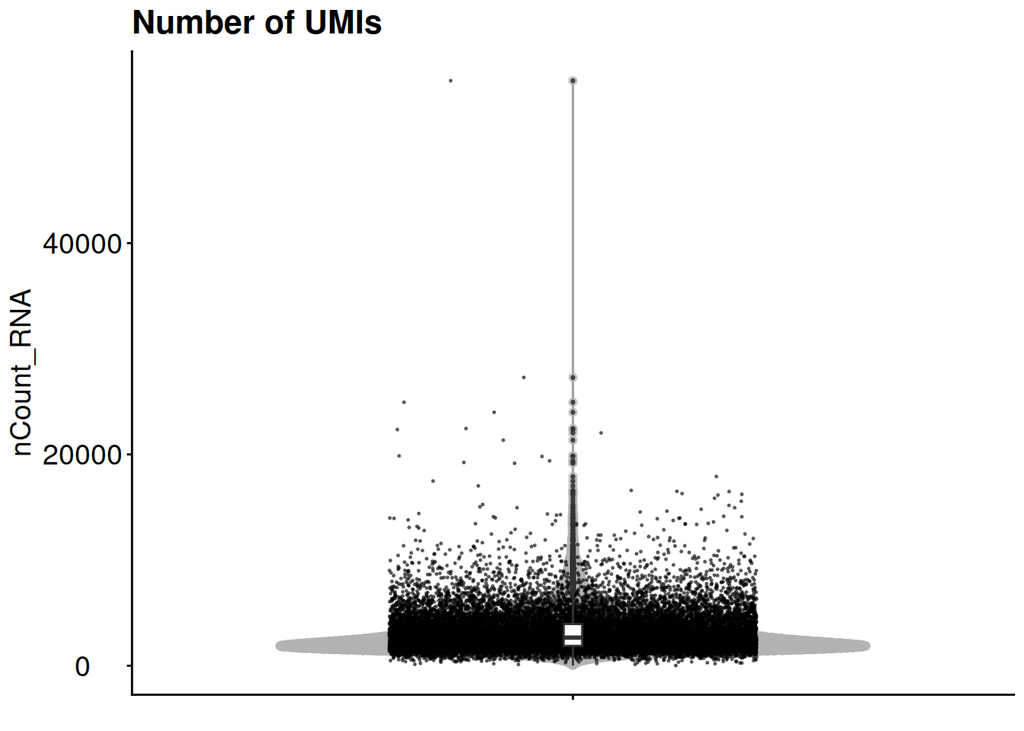

```r
##~~~~~~~~~~~~~~~~~~~~~ Number of UMIs ~~~~~~~~~~~~~~~~~~~~~~~~~~~~~

plotColData(sce, y="sum") +
  geom_point(size=0.25, alpha=0.5, position = position_jitter(width=0.25,seed = 12345))+
  geom_boxplot(width=0.025, outlier.size = 0.5, outlier.alpha = 0.8)+
  xlab(NULL)+
  ylab("nCount_RNA")+
  ggtitle("Number of UMIs")+
  theme(axis.text.y=element_text(size = 14,hjust = 0.5), title = element_text(size = 14,hjust = 0.5))
```

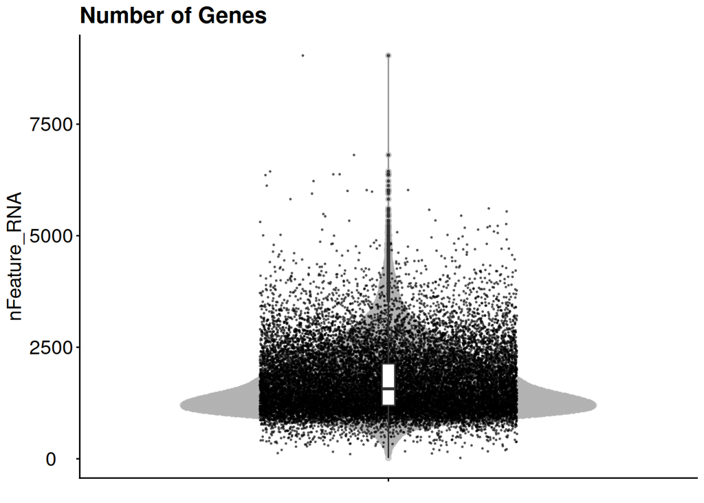

```r
##~~~~~~~~~~~~~~~~~~~~~ Number of Genes ~~~~~~~~~~~~~~~~~~~~~~~~~~~~~

plotColData(sce, y="detected") +
  geom_point(size=0.25, alpha=0.5, position = position_jitter(width=0.25,seed = 12345))+
  geom_boxplot(width=0.025, outlier.size = 0.5, outlier.alpha = 0.8)+
  xlab(NULL)+
  ylab("nFeature_RNA")+
  ggtitle("Number of Genes")+
  theme(axis.text.y=element_text(size = 14,hjust = 0.5), title = element_text(size = 14,hjust = 0.5))
```

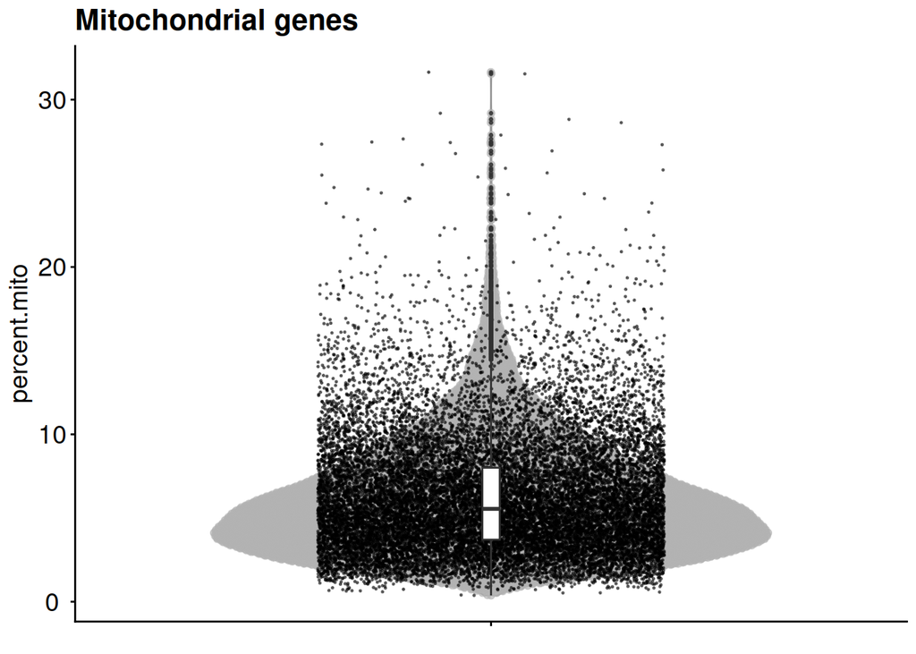

```r
##~~~~~~~~~~~~~~~~~~~~~ Mitochondrial Genes ~~~~~~~~~~~~~~~~~~~~~~~~~~~~~

plotColData(sce, y="subsets_Mito_percent") +
  geom_point(size=0.25, alpha=0.5, position = position_jitter(width=0.25,seed = 12345))+
  geom_boxplot(width=0.025, outlier.size = 0.5, outlier.alpha = 0.8)+
  xlab(NULL)+
  ylab("percent.mito")+
  ggtitle("Mitochondrial genes")+
  theme(axis.text.y=element_text(size = 14,hjust = 0.5), title = element_text(size = 14,hjust = 0.5))
```

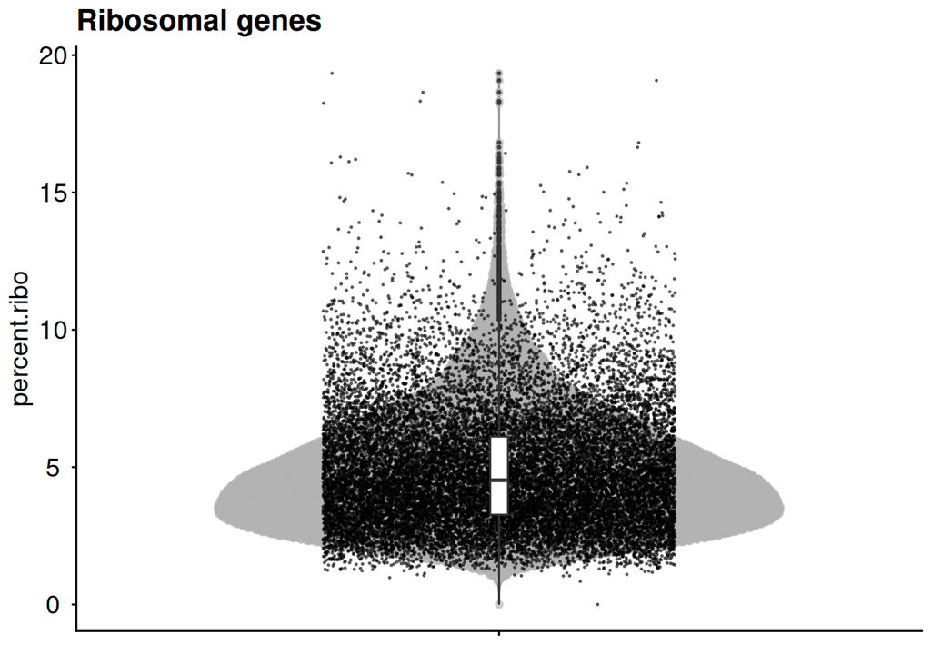

```r
##~~~~~~~~~~~~~~~~~~~~~ Ribosomal Genes ~~~~~~~~~~~~~~~~~~~~~~~~~~~~~

plotColData(sce, y="subsets_Ribo_percent") +
  geom_point(size=0.25, alpha=0.5, position = position_jitter(width=0.25,seed = 12345))+
  geom_boxplot(width=0.025, outlier.size = 0.5, outlier.alpha = 0.8)+
  xlab(NULL)+
  ylab("percent.ribo")+
  ggtitle("Ribosomal genes")+
  theme(axis.text.y=element_text(size = 14,hjust = 0.5), title = element_text(size = 14,hjust = 0.5))
```

## 4.3 Relation between nUMI and nGene deteced

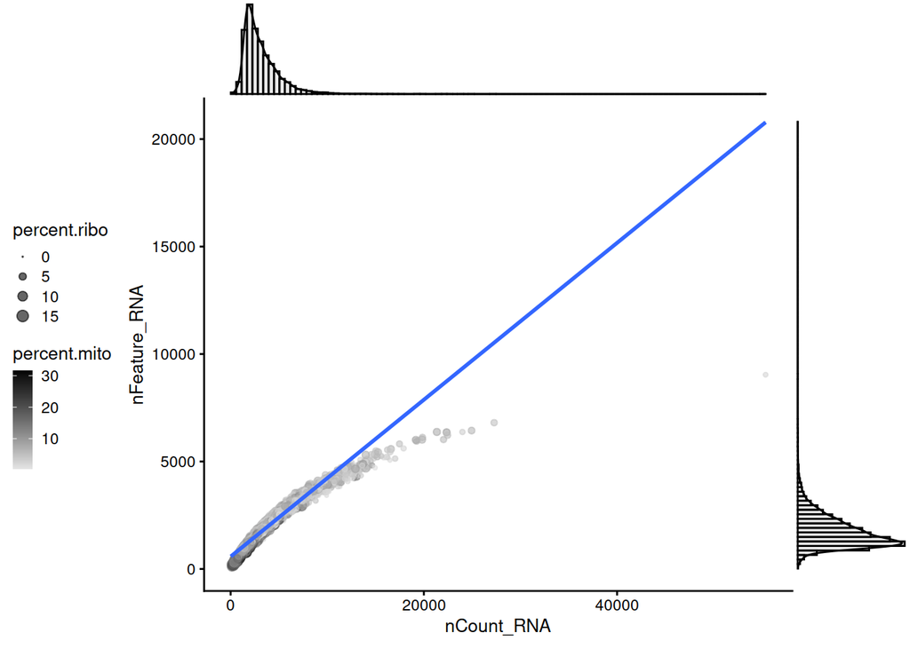

```r
##~~~~~~~~~~~~~~~~~~~~~ nGenes vs nUMIs ~~~~~~~~~~~~~~~~~~~~~~~~~~~~~

p1 <- plotColData(sce, x="sum" , y="detected",
            colour_by = "subsets_Mito_percent",
            size_by = "subsets_Ribo_percent") +
  scale_colour_gradient(aesthetics = c("colour"),low = "gray90", high = "black") +
  scale_size_area(max_size = 3)+
  geom_smooth(method = "lm")+
  xlab("nCount_RNA")+
  ylab("nFeature_RNA")+
  ggtitle(NULL) +
  theme(legend.position = "left") +
  labs(colour="percent.mito") +
  guides(size=guide_legend("percent.ribo"))

p1 <- ggMarginal(p1, type = "densigram",bins=100, fill="grey", alpha=.3)

p1
```

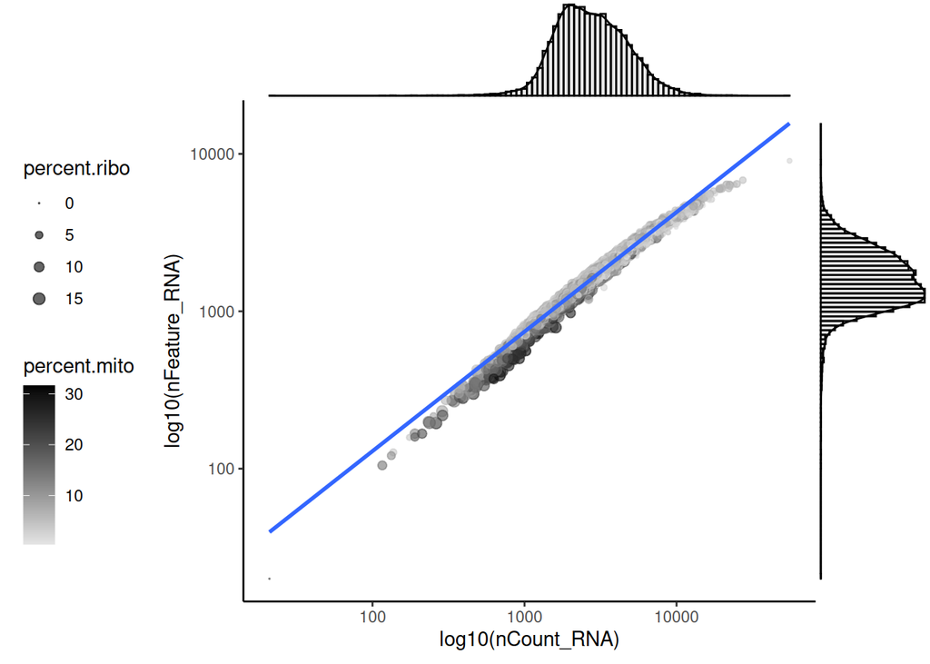

```r
##~~~~~~~~~~~~~~~~~~~~~ log10(nGenes vs nUMIs) ~~~~~~~~~~~~~~~~~~~~~~~~~~~~~

p2 <- plotColData(sce, x="sum", y="detected",
                           colour_by="subsets_Mito_percent",
                           size_by="subsets_Ribo_percent") +
  scale_x_log10() + scale_y_log10() +
  scale_colour_gradient(aesthetics = c("colour"),low = "gray90", high = "black") +
  scale_size_area(max_size = 3)+
  geom_smooth(method = "lm", show.legend = FALSE)+
  xlab("log10(nCount_RNA)")+
  ylab("log10(nFeature_RNA)") +
  theme_classic() +
  theme(legend.position = "left") +
  labs(colour="percent.mito") +
  guides(size=guide_legend("percent.ribo"))
p2 <- ggMarginal(p2, type = "densigram",bins=100, fill="grey", alpha=.3)
p2
```

**if hto==TRUE** `line 284`

```r
mito_max <- 15
min_nfeatures <- log10(200)
```

```r
if (sum(sce$subsets_Mito_percent <= mito_max) == length(sce$subsets_Mito_percent <= mito_max)){
  p <- plotColData(sce, x="detected", y="subsets_Mito_percent",
            color_by = "consensus_call_global")+
  geom_hline(aes(yintercept = mito_max), colour = "red", linetype = 2) +
  geom_vline(aes(xintercept = 10^min_nfeatures), colour = "red", linetype = 2) +
  xlab("nFeature_RNA")+
  ylab("percent.mito")+
  annotate(geom = "text",size=4,
           label = paste0(as.numeric(table( sce$subsets_Mito_percent <= mito_max)[1])," cells remain"),
           x = max(sce$detected)-1000, y = mito_max+5)
  p <- ggMarginal(p, type = "densigram",bins=100, fill="grey",  alpha=0.3)

  p
}
```

```r
if(sum(sce$subsets_Mito_percent > mito_max)==length(sce$subsets_Mito_percent <= mito_max)){
  p <- plotColData(sce, x="detected", y="subsets_Mito_percent",
            color_by = "consensus_call_global")+
  geom_hline(aes(yintercept = mito_max), colour = "red", linetype = 2) +
  geom_vline(aes(xintercept = 10^min_nfeatures), colour = "red", linetype = 2) +
  xlab("nFeature_RNA")+
  ylab("percent.mito")+
  annotate(geom = "text",size=4,
           label = paste0(as.numeric(table( sce$subsets_Mito_percent <= mito_max)[1])," cells removed"),
           x = max(sce$detected)-1000, y = mito_max+5)
  p <- ggMarginal(p, type = "densigram",bins=100, fill="grey",  alpha=0.3)

  p
}
```

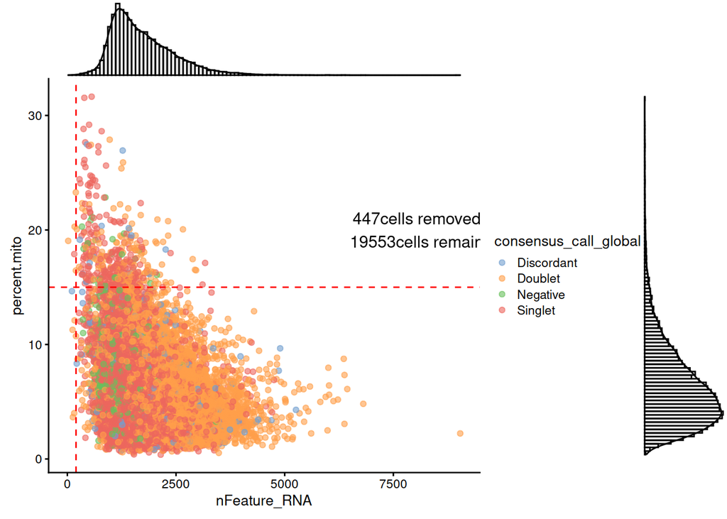

```r
if(sum(sce$subsets_Mito_percent <= mito_max)!=length(sce$subsets_Mito_percent <= mito_max)&
   sum(sce$subsets_Mito_percent > mito_max)!=length(sce$subsets_Mito_percent <= mito_max)){

  p <- plotColData(sce, x="detected", y="subsets_Mito_percent",
            color_by = "consensus_call_global")+
  geom_hline(aes(yintercept = mito_max), colour = "red", linetype = 2) +
  geom_vline(aes(xintercept = 10^min_nfeatures), colour = "red", linetype = 2) +
  xlab("nFeature_RNA")+
  ylab("percent.mito")+
  annotate(geom = "text",size=4,
           label = paste0(as.numeric(table( sce$subsets_Mito_percent <= mito_max)[1]),"cells removed\n",
                          as.numeric(table( sce$subsets_Mito_percent <= mito_max)[2]), "cells remain"),
           x = max(sce$detected)-1000, y = mito_max+5)
  p <- ggMarginal(p, type = "densigram",bins=100, fill="grey",  alpha=0.3)

  p
}
```

**closed if statement** `line 284`

**if hto==FALSE** `line 340`

```r
if(sum(sce$subsets_Mito_percent <= mito_max)==length(sce$subsets_Mito_percent <= mito_max)){
  p <- plotColData(sce, x="detected", y="subsets_Mito_percent")+
  geom_hline(aes(yintercept = mito_max), colour = "red", linetype = 2) +
  geom_vline(aes(xintercept = 10^min_nfeatures), colour = "red", linetype = 2) +
  xlab("nFeature_RNA")+
  ylab("percent.mito")+
  annotate(geom = "text",size=4,
           label = paste0(as.numeric(table( sce$subsets_Mito_percent <= mito_max)[1]),"cells removed\n"),
           x = max(sce$detected)-1000, y = mito_max+5)
  p <- ggMarginal(p, type = "densigram",bins=100, fill="grey",  alpha=0.3)

  p
}
```

```r
if(sum(sce$subsets_Mito_percent > mito_max)==length(sce$subsets_Mito_percent <= mito_max)){
  p <- plotColData(sce, x="detected", y="subsets_Mito_percent")+
  geom_hline(aes(yintercept = mito_max), colour = "red", linetype = 2) +
  geom_vline(aes(xintercept = 10^min_nfeatures), colour = "red", linetype = 2) +
  xlab("nFeature_RNA")+
  ylab("percent.mito")+
  annotate(geom = "text",size=4,
           label = paste0(as.numeric(table( sce$subsets_Mito_percent <= mito_max)[1]),"cells removed\n"),
           x = max(sce$detected)-1000, y = mito_max+5)
  p <- ggMarginal(p, type = "densigram",bins=100, fill="grey",  alpha=0.3)

  p
}
```

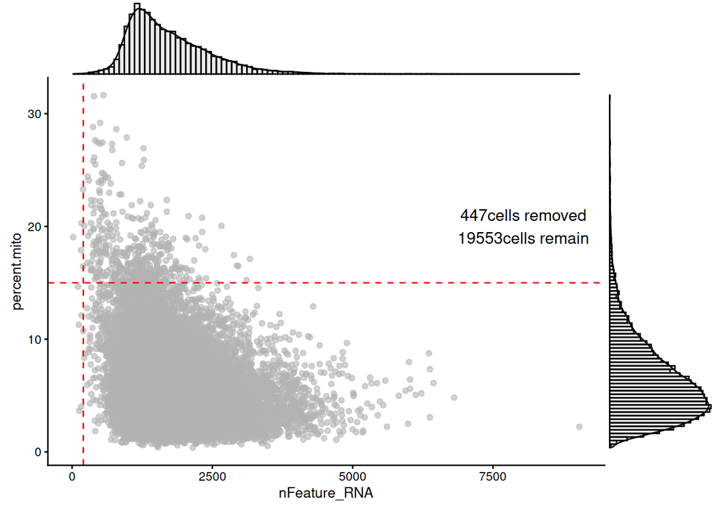

```r
if(sum(sce$subsets_Mito_percent <= mito_max)!=length(sce$subsets_Mito_percent <= mito_max)&sum(sce$subsets_Mito_percent > mito_max)!=length(sce$subsets_Mito_percent <= mito_max)){
  p <- plotColData(sce, x="detected", y="subsets_Mito_percent")+
  geom_hline(aes(yintercept = mito_max), colour = "red", linetype = 2) +
  geom_vline(aes(xintercept = 10^min_nfeatures), colour = "red", linetype = 2) +
  xlab("nFeature_RNA")+
  ylab("percent.mito")+
  annotate(geom = "text",size=4,
           label = paste0(as.numeric(table( sce$subsets_Mito_percent <= mito_max)[1]),"cells removed\n",
                          as.numeric(table( sce$subsets_Mito_percent <= mito_max)[2]), "cells remain"),
           x = max(sce$detected)-1000, y = mito_max+5)
  p <- ggMarginal(p, type = "densigram",bins=100, fill="grey",  alpha=0.3)

  p
}
```

**closed if statement** `line 340`

## 4.4 Filtering metrics

### 4.4.1 setting a column where to store QC control information

```r
# filtering by mito genes: sce[, sce$subsets_Mito_percent <= mito_max]
# filtering by min_rna : sce_Mito_filt[, log10(sce_Mito_filt$detected) >= min_nfeatures]
# filtering by valid_cells: sce_mito_rna_filt[, sce_mito_rna_filt$validCells]
# column name: qc
# gplots::venn
```

```r
colData(sce)$qc <- NULL
colData(sce)$qc <- gsub("TRUE", "passed", gsub("FALSE", "fails_maxMito", sce$subsets_Mito_percent <= mito_max))
colData(sce)$qc <-
  replace(x=colData(sce)$qc,
          list=which(sce$qc == "passed"),
          values=gsub(
            "TRUE", "passed", gsub("FALSE", "fails_minFeat", log10(sce[,sce$qc == "passed"]$detected)
                                   >=min_nfeatures)))

lm <- lm(log10(sce[, sce$qc == "passed"]$detected) ~ log10(sce[, sce$qc == "passed"]$sum))

colData(sce)$qc <-
  replace(x=colData(sce)$qc,
          list=which(sce$qc =="passed"),
          values=gsub(
            "TRUE", "passed",
            gsub("FALSE", "fails_lm",
                 log10(sce[, sce$qc == "passed"]$detected) >
                   log10(sce[, sce$qc == "passed"]$sum) * lm$coefficients[2] + (lm$coefficients[1]-.09))))
```

##~~~~~~~~~~~~~~~~~~~~~ Filter cells based on maxMito threshold ~~~~~~~~~~~~~~~~~~~~~~~~~~~~~

`line 392`

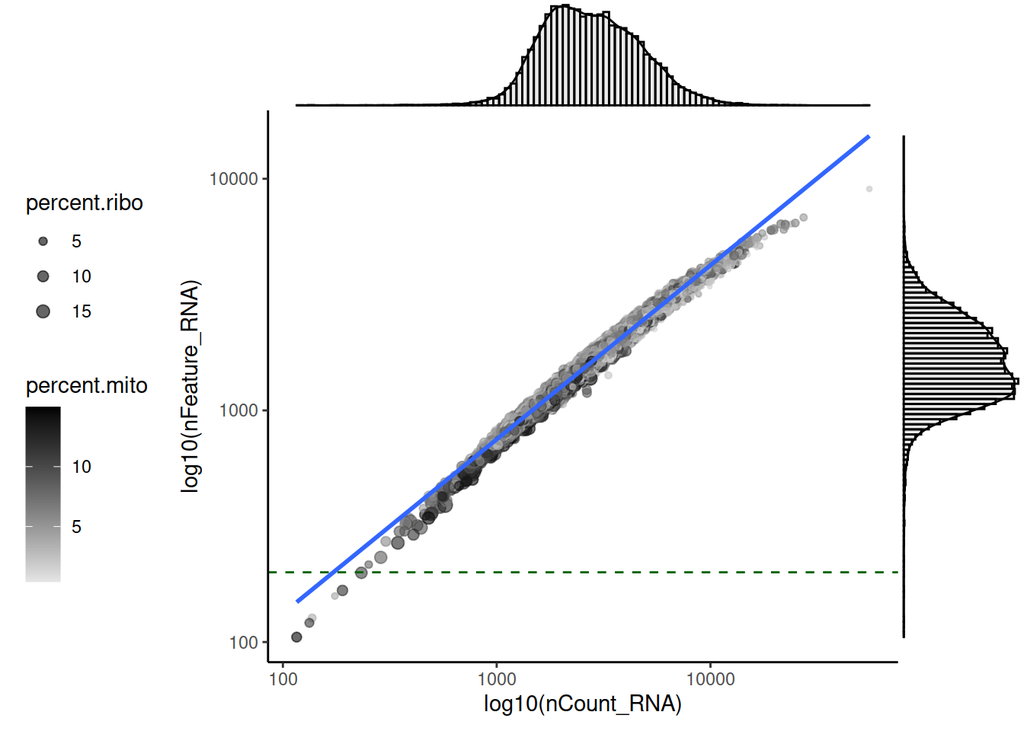

```r
p1 <- plotColData(sce[, !sce$qc == "fails_maxMito"], x="sum", y="detected",
            color_by = "subsets_Mito_percent",
            size_by = "subsets_Ribo_percent") +
  scale_x_log10() + scale_y_log10() +
  scale_colour_gradient(aesthetics = c("colour"),low = "gray90", high = "black") +
  scale_size_area(max_size = 3)+
  geom_smooth(method = "lm", show.legend = FALSE)+
  geom_hline(aes(yintercept = 10^min_nfeatures), colour = "darkgreen", linetype = 2)+
  xlab("log10(nCount_RNA)")+
  ylab("log10(nFeature_RNA)") +
  theme_classic() +
  theme(legend.position = "left") +
  labs(colour="percent.mito") +
  guides(size=guide_legend("percent.ribo"))
p1 <- ggMarginal(p1, type = "densigram",bins=100, fill="grey", alpha=.3)
p1
```

##~~~~~~~~~~~~~~~~~~~~~ Filter cells based on maxMito & minFeat ~~~~~~~~~~~~~~~~~~~~~~~~~~~~~ `line 412`

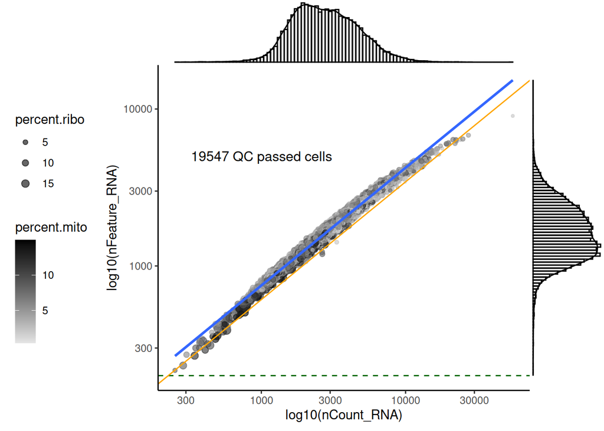

```r
p2 <- plotColData(sce[, !sce$qc == "fails_maxMito" & !sce$qc == "fails_minFeat"],
                  x="sum", y="detected",
        colour_by="subsets_Mito_percent",
        size_by="subsets_Ribo_percent") +
  scale_x_log10() + scale_y_log10() +
  scale_colour_gradient(aesthetics = c("colour"),low = "gray90", high = "black") +
  scale_size_area(max_size = 3)+
  geom_smooth(method = "lm", show.legend = FALSE)+
  geom_hline(aes(yintercept = 10^min_nfeatures), colour = "darkgreen", linetype = 2)+
  geom_abline(intercept = lm$coefficients[1] - 0.09, slope = lm$coefficients[2], color="orange") +
  xlab("log10(nCount_RNA)")+
  ylab("log10(nFeature_RNA)") +
  theme_classic() +
  theme(legend.position = "left") +
  labs(colour="percent.mito") +
  guides(size=guide_legend("percent.ribo")) +
  annotate(geom = "text",size=4, label = paste0(dim(sce[, !sce$qc == "fails_maxMito" & !sce$qc == "fails_minFeat"])[2], " QC passed cells"),
           x = 1000, y = 5000)
p2 <- ggMarginal(p2, type = "densigram",bins=100, fill="grey", alpha=.3)
p2
```

# cells to exclude lie below an intercept offset of -0.09

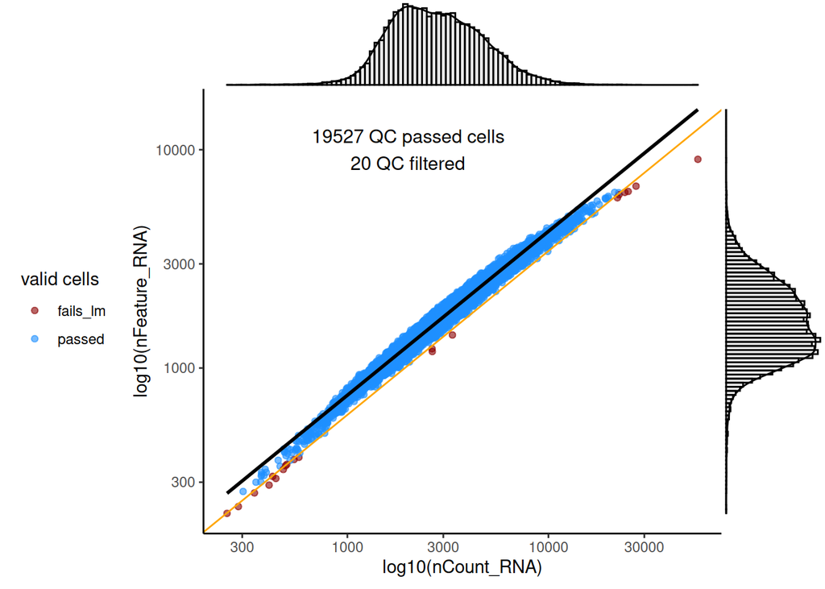

```r
p3 <- plotColData(sce[, !sce$qc == "fails_maxMito" & !sce$qc == "fails_minFeat"],
                  x="sum", y="detected",
            colour_by = "qc") +
  scale_x_log10() + scale_y_log10() +
  scale_colour_manual(values = c("darkred", "dodgerblue")) +
  geom_smooth(method = "lm", color="black",show.legend = FALSE)+
  geom_abline(intercept = lm$coefficients[1] - 0.09, slope = lm$coefficients[2], color="orange") +
  xlab("log10(nCount_RNA)")+
  ylab("log10(nFeature_RNA)") +
  theme_classic() +
  theme(legend.position = "left") +
  labs(colour="valid cells") +
  annotate(geom = "text",size=4,
           label = paste0(
             table(sce[, !sce$qc == "fails_maxMito" & !sce$qc == "fails_minFeat"]$qc)[[2]], " QC passed cells\n",
             table(sce[, !sce$qc == "fails_maxMito" & !sce$qc == "fails_minFeat"]$qc)[[1]], " QC filtered"),
           x = 2000, y = 10000)

p3 <- ggMarginal(p3, type = "densigram",bins=100, fill="grey", alpha=.3)

p3
```

**closed if statement** `line 207`

# up to here belong to if the length of mito genes are greater or equal to 1

**if statement** `line 450`

```r
if(!length(grep("^mt-", rownames(sce))) >=1)
```

In this case, QC metrics are not computed.

This part is skipped as it is the same as above. `lines 450 to 509`

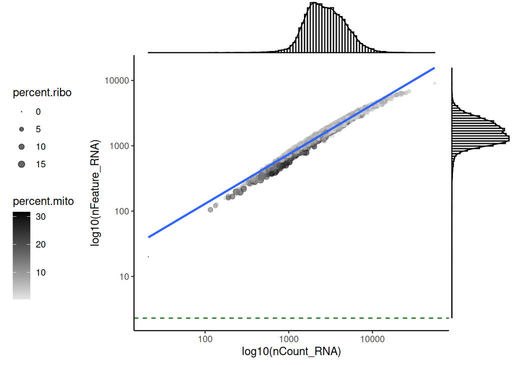

```r
##~~~~~~~~~~~~~~~~~~~~~ log10(nGenes vs nUMIs) ~~~~~~~~~~~~~~~~~~~~~~~~~~~~~

p1 <- plotColData(sce, x="sum", y="detected",
                           colour_by="subsets_Mito_percent",
                           size_by="subsets_Ribo_percent") +
  scale_x_log10() + scale_y_log10() +
  scale_colour_gradient(aesthetics = c("colour"),low = "gray90", high = "black") +
  scale_size_area(max_size = 3)+
  geom_smooth(method = "lm", show.legend = FALSE)+
  geom_hline(aes(yintercept=min_nfeatures), colour="darkgreen", linetype=2)+
  xlab("log10(nCount_RNA)")+
  ylab("log10(nFeature_RNA)") +
  theme_classic() +
  theme(legend.position = "left") +
  labs(colour="percent.mito") +
  guides(size=guide_legend("percent.ribo"))
p1 <- ggMarginal(p1, type = "densigram",bins=100, fill="grey", alpha=.3)
p1
```

**Continuing with line 510**

##~~~~~~~~~~~~~~~~~~~~~ Removing unvalid cells ~~~~~~~~~~~~~~~~~~~~~~~~~~~~~ `line 510`

Here we retain those which passed all the filters, in the `qc` column as *passed*.

##~~~~~~~~~~~~~~~~~~~~~ Plot final QC metrics ~~~~~~~~~~~~~~~~~~~~~~~~~~~~~

**After filtering**

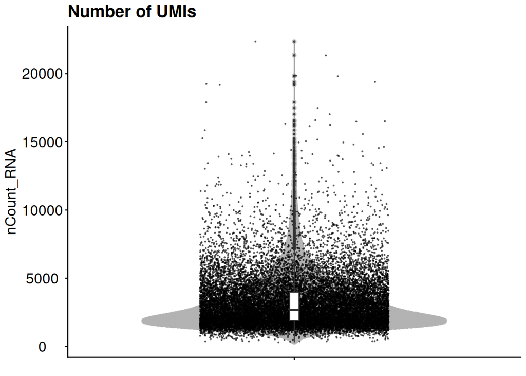

```r
##~~~~~~~~~~~~~~~~~~~~~ Number of UMIs ~~~~~~~~~~~~~~~~~~~~~~~~~~~~~

plotColData(sce[, !sce$qc == "fails_maxMito" & !sce$qc == "fails_minFeat" & !sce$qc == "fails_lm"],
            y="sum") +
  geom_point(size=0.25, alpha=0.5, position = position_jitter(width=0.25,seed = 12345))+
  geom_boxplot(width=0.025, outlier.size = 0.5, outlier.alpha = 0.8)+
  xlab(NULL)+
  ylab("nCount_RNA")+
  ggtitle("Number of UMIs")+
  theme(axis.text.y=element_text(size = 14,hjust = 0.5), title = element_text(size = 14,hjust = 0.5))
```

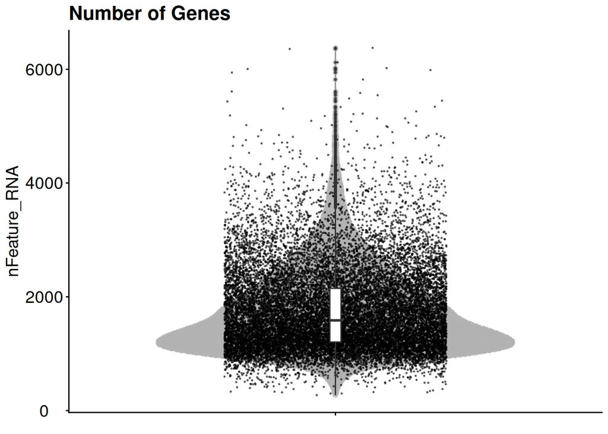

```r
##~~~~~~~~~~~~~~~~~~~~~ Number of Genes ~~~~~~~~~~~~~~~~~~~~~~~~~~~~~

plotColData(sce[, !sce$qc == "fails_maxMito" & !sce$qc == "fails_minFeat" & !sce$qc == "fails_lm"],
            y="detected") +
  geom_point(size=0.25, alpha=0.5, position = position_jitter(width=0.25,seed = 12345))+
  geom_boxplot(width=0.025, outlier.size = 0.5, outlier.alpha = 0.8)+
  xlab(NULL)+
  ylab("nFeature_RNA")+
  ggtitle("Number of Genes")+
  theme(axis.text.y=element_text(size = 14,hjust = 0.5), title = element_text(size = 14,hjust = 0.5))
```

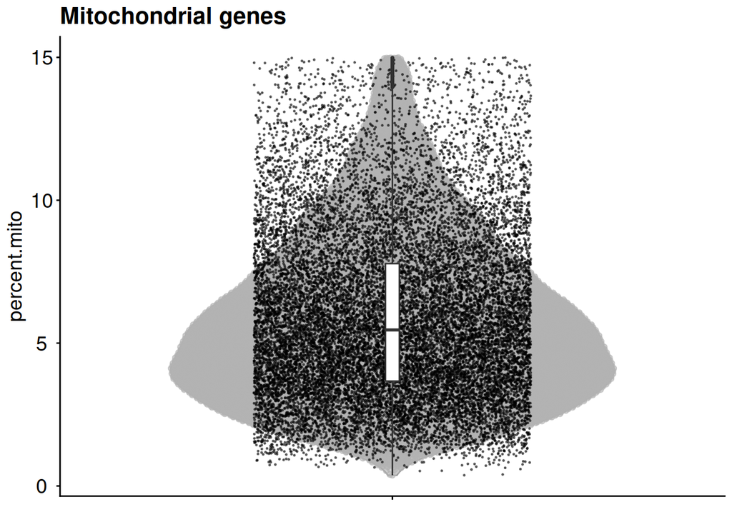

```r
##~~~~~~~~~~~~~~~~~~~~~ Mitochondrial Genes ~~~~~~~~~~~~~~~~~~~~~~~~~~~~~

plotColData(sce[, !sce$qc == "fails_maxMito" & !sce$qc == "fails_minFeat" & !sce$qc == "fails_lm"],
            y="subsets_Mito_percent") +
  geom_point(size=0.25, alpha=0.5, position = position_jitter(width=0.25,seed = 12345))+
  geom_boxplot(width=0.025, outlier.size = 0.5, outlier.alpha = 0.8)+
  xlab(NULL)+
  ylab("percent.mito")+
  ggtitle("Mitochondrial genes")+
  theme(axis.text.y=element_text(size = 14,hjust = 0.5), title = element_text(size = 14,hjust = 0.5))
```

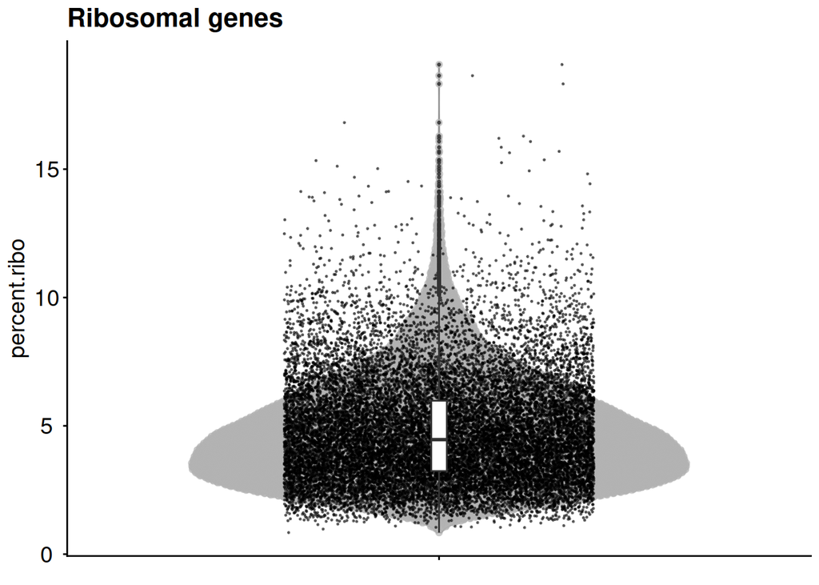

```r
##~~~~~~~~~~~~~~~~~~~~~ Ribosomal Genes ~~~~~~~~~~~~~~~~~~~~~~~~~~~~~

plotColData(sce[, !sce$qc == "fails_maxMito" & !sce$qc == "fails_minFeat" & !sce$qc == "fails_lm"],
            y="subsets_Ribo_percent") +
  geom_point(size=0.25, alpha=0.5, position = position_jitter(width=0.25,seed = 12345))+
  geom_boxplot(width=0.025, outlier.size = 0.5, outlier.alpha = 0.8)+
  xlab(NULL)+
  ylab("percent.ribo")+
  ggtitle("Ribosomal genes")+
  theme(axis.text.y=element_text(size = 14,hjust = 0.5), title = element_text(size = 14,hjust = 0.5))
```